[figure not shown]

# **GA-NLP Mid-term Project: Support Ticket Categorization**

## **Business Context**

In today's dynamic business landscape, organizations are increasingly recognizing the pivotal role customer feedback plays in shaping the trajectory of their products and services. The ability to **swiftly and effectively respond to customer input** not only fosters enhanced customer experiences but also serves as a catalyst for growth, prolonged customer engagement, and the nurturing of lifetime value relationships.

As a dedicated Product Manager or Product Analyst, staying attuned to the voice of your customers is not just a best practice; it's a strategic imperative.

While your organization may be inundated with a wealth of customer-generated feedback and support tickets, your role entails much more than just processing these inputs. To make your efforts in managing customer experience and expectations truly impactful, you need a structured approach – a method that allows you to discern the most pressing issues, set priorities, and allocate resources judiciously.

One of the most effective strategies at your disposal as an organization is to harness the power of automated Support Ticket Categorization - **done in the modern day using Large Language Models and Generative AI.**

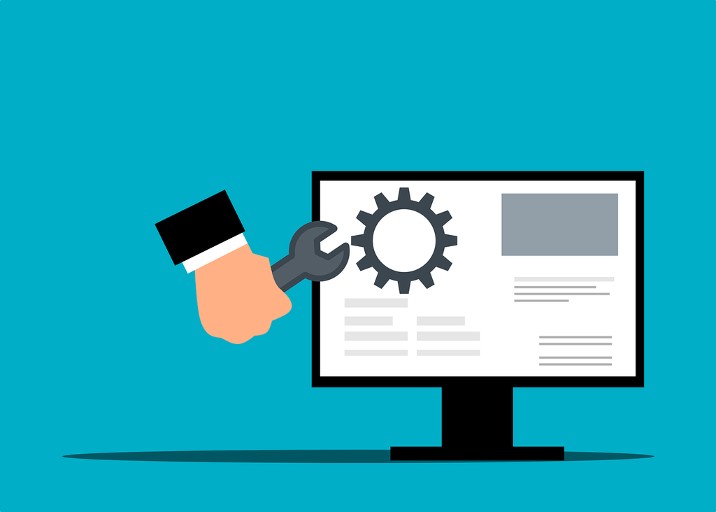

## **Project Objective**

Develop a Generative AI application using a Large Language Model to **automate the classification and processing of support tickets.** The application will aim to predict ticket categories, assign priority, suggest estimated resolution times, generate responses based on sentiment analysis, and store the results in a structured DataFrame.

## **Expected Output**

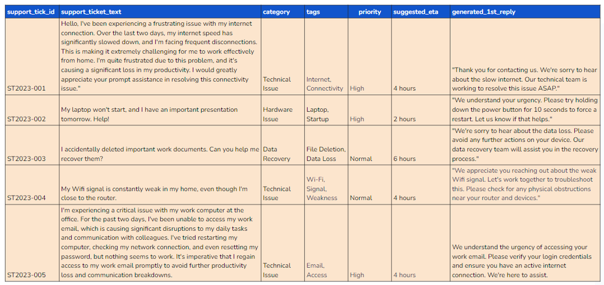

## Removing Warnings"

```python
import warnings
warnings.filterwarnings('ignore')
```

## Installing Dependencies for Llama-2

```python
!pip install lida
```

[output not shown]

## **Model Loading**

```python
# Installation for GPU llama-cpp-python
!CMAKE_ARGS="-DLLAMA_CUBLAS=on" FORCE_CMAKE=1 pip install llama-cpp-python --force-reinstall --upgrade --no-cache-dir -q
```

[output not shown]

```python
# Install the hugging face hub
!pip install huggingface_hub
```

```
     ━━━━━━━━━━━━━━━━━━━━━━━━━━━━━━━━━━━━━━━━ 302.0/302.0 kB 5.9 MB/s eta 0:00:00
```

### **Q1: Write Python code that imports the 'hf_hub_download' function from the 'huggingface_hub' library and also imports the 'Llama' class from the 'llama_cpp' library.**

### **Ensure that the code is correctly formatted and ready for execution.** **(5 Marks)**

```python
from huggingface_hub import hf_hub_download
from llama_cpp import Llama
```

```python
from llama_cpp import Llama
```

```python
# Define the model name or path as a string (You can find this info from hugging face website)

model_name_or_path ="TheBloke/Llama-2-13B-chat-GGUF"

# Define the model basename as a string, indicating it's in the gguf format

model_basename = "llama-2-13b-chat.Q5_K_M.gguf" # the model is in gguf format
```

```python
# Download the model from the Hugging Face Hub using the 'hf_hub_download' function
# by specifying the 'repo_id' and 'filename'
model_path = hf_hub_download(
    repo_id=model_name_or_path,
    filename=model_basename
    )
```

```python
# Create an instance of the 'Llama' class with specified parameters
# remove the blank spaces and complete the code
```

```python
lcpp_llm = Llama(
        model_path=model_path,
        n_threads=2,  # CPU cores
        n_batch=512,  # Should be between 1 and n_ctx, consider the amount of VRAM in your GPU.
        n_gpu_layers=43,  # Change this value based on your model and your GPU VRAM pool.
        n_ctx=4096,  # Context window
    )
```

```
AVX = 1 | AVX2 = 1 | AVX512 = 0 | AVX512_VBMI = 0 | AVX512_VNNI = 0 | FMA = 1 | NEON = 0 | ARM_FMA = 0 | F16C = 1 | FP16_VA = 0 | WASM_SIMD = 0 | BLAS = 1 | SSE3 = 1 | SSSE3 = 1 | VSX = 0 |
```

### **Q2: Define the System Message** **(7 Marks)**

Write a Python function called **generate_llama_response** that takes a single parameter, support_ticket_text, which represents the user's support ticket text. Inside the function, you should perform the following tasks:

Define a system message as a string and assign it to the variable system_message.

- **Combine the support_ticket_text and system_message to create a prompt string.**

*Generate a response from the LLaMA model using the lcpp_llm instance with the following parameters:*

- prompt should be the combined prompt string.
- max_tokens should be set to 256.
- temperature should be set to 0.
- top_p should be set to 0.95.
- repeat_penalty should be set to 1.2.
- top_k should be set to 50.
- stop should be set as a list containing 'INST'.
- echo should be set to False. Extract and return the response text from the generated response.

Don't forget to provide a value for the system_message variable before using it in the function.

*What content and instructions should be included in the system message to guide the technical assistant when processing support tickets? Please provide a detailed description of the information and guidelines that the system message should contain.*

Here's a detailed breakdown of what should be included:

- **Introduction (System Role):** Begin with an introductory statement that establishes the role of the system message. In this case, it's acting as a guide for a technical assistant.
- **Ticket Categorization:** Explain the primary task of the technical assistant, which is to classify the support ticket into specific categories. In this example, the categories are:
  - Technical Issues
  - Hardware Issues
  - Data Recovery
- **Response Options:** Clearly state that the assistant should only respond with one of the predefined categories, emphasizing that other responses are not acceptable.
- **Sub-Tasks:** Outline the secondary tasks that the technical assistant should perform once the category is identified. These sub-tasks include:
  - **Creating Tags:** Instruct the assistant to create tags that will help further classify the ticket.
  - **Assigning Priority:** Specify that the assistant should assign a priority level (e.g., "High" or "Normal") based on their understanding of the text.
  - **Suggesting ETA:** Guide the assistant to provide an estimated time for resolving the issue mentioned in the ticket.
  - **Generating 1st Reply (Sentiment-Based):** Emphasize the importance of crafting a response that aligns with the sentiment expressed in the ticket.
- **General Instructions:** Offer general instructions that should be followed throughout the ticket processing, such as:
  - **Categorization:** Reiterate that the assistant should categorize the ticket only into the predefined categories.
  - **Reading Carefully:** Stress the importance of reading the support ticket text thoroughly and considering the overall sentiment before responding.
  - **Tone:** Emphasize that the tone of all responses should be polite and professional.
  - **Output Format:** Clearly specify the desired output format for the responses generated by the assistant. In this case, the output should be in JSON format.

##### **The output of the model should be in JSON format**

```python
from typing import Text
def generate_llama_response(support_ticket_text):

    # System message
    system_message ="""
    [INST]<<SYS>> You are a professional technical assistant,
Your primary objective is classifying customer support tickets into three specific categories: 'Hardware issue’, ‘Technical issue’ and 'Data Recovery’. Consider the overall sentiment before responding with one of the predefined categories

The output should be in the form of a strict JSON format with the following:

{
"category": "<Based on the ticket text, classify the issue as either 'Hardware issue’, ‘Technical issue' or 'Data Recovery', Example Inputs and Expected Outputs: "My laptop refuses to start." -> "Hardware issue", "My internet connection is slow." -> "Technical issue'>",
}

{
"priority": "<Based on the urgency and importance of the issue described in the ticket, assign a priority level from 'High', or 'Normal', Example Inputs and Expected Outputs: "Urgent help required! My laptop refuses to start." -> "High", "My smartphone battery drains quickly." -> "Normal'>",
}

{
"suggested_eta": "<Based on the complexity of the issue in the ticket, suggest an estimated resolution time, Example Inputs and Expected Outputs: "I've accidentally deleted essential work documents." -> "6 hours", "My internet connection is slow." -> "4 hours", "My smartphone battery drains quickly." -> "2 hours'.>"
}

Please read the support ticket text carefully, and ensure your response aligns with the sentiment expressed in the ticket.


<</SYS>>[/INST]
    """

    # Combine user_prompt and system_message to create the prompt
    prompt = f"{support_ticket_text}\n{system_message}"

    # Generate a response from the LLaMA model
    response = lcpp_llm(
        prompt=prompt,
        max_tokens=256,
        temperature=0,
        top_p=0.95,
        repeat_penalty=1.2,
        top_k=50,
        stop=['INST'],
        echo=False
    )

    # Extract and return the response text
    response_text = response["choices"][0]["text"]  ### Fill in the blank
    return response_text
```

### **Q3: Loading our Dataset (2 Marks)**

```python
from google.colab import drive
drive.mount('/content/drive')
```

```python
# Import the pandas library and alias it as 'pd'
import pandas as pd

# Read a CSV file into a DataFrame and store it in the 'data' variable
data = pd.read_csv('/content/drive/MyDrive/NLP/Support_ticket_text_data_mid_term.csv')
```

- After reading the CSV file into the 'data' DataFrame, how can you determine the shape of the DataFrame, and what information does 'data.shape' provide?
- What does 'data.head()' do, and how can it be used to inspect the contents of the DataFrame?

### **Q4: Create a new column in the DataFrame called 'llama_response' and populate it with responses generated by applying the 'generate_llama_response' function to each 'support_ticket_text' in the DataFrame ( 5Marks)**

```python
# Apply a function to each element in the 'support_ticket_text' column of the DataFrame 'data'
# The applied function, in this case, is a lambda function.

# The lambda function takes a single argument 'x', representing each individual 'support_ticket_text' in the column.

# Inside the lambda function:
# - 'generate_llama_response(x)' is called to generate a response based on the 'support_ticket_text'.
# - The result of 'generate_llama_response(x)' is assigned to a new column called 'llama_response' in the DataFrame 'data'.

# Example - data['llama_response'] = data['support_ticket_text'].apply(lambda x: generate_llama_response(x))
```

```python
data['llama_response'] = data['support_ticket_text'].apply(lambda x: generate_llama_response(x))
```

[output not shown]

```python
## Check the new_column added
data.head(10)
```

|  | support_tick_id | support_ticket_text | llama_response |
| --- | --- | --- | --- |
| 0 | ST2023-006 | My internet connection has significantly slowe... | {\n"category": "Technical issue",\n"priority"... |
| 1 | ST2023-007 | Urgent help required! My laptop refuses to sta... | {\n"category": "Hardware issue",\n"priority":... |
| 2 | ST2023-008 | I've accidentally deleted essential work docum... | {\n"category": "Data Recovery",\n"priority": ... |
| 3 | ST2023-009 | Despite being in close proximity to my Wi-Fi r... | {\n"category": "Technical issue",\n"priority"... |
| 4 | ST2023-010 | My smartphone battery is draining rapidly, eve... | {\n"category": "Technical issue",\n"priority"... |
| 5 | ST2023-011 | I'm locked out of my online banking account an... | {\n"category": "Technical issue",\n"priority"... |
| 6 | ST2023-012 | My computer's performance is sluggish, severel... | {\n"category": "Hardware issue",\n"priority":... |
| 7 | ST2023-013 | I'm experiencing a recurring blue screen error... | {\n"category": "Hardware issue",\n"priority":... |
| 8 | ST2023-014 | My external hard drive isn't being recognized ... | {\n"category": "Data Recovery",\n"priority": ... |
| 9 | ST2023-015 | The graphics card in my gaming laptop seems to... | {\n"category": "Hardware issue",\n"priority":... |

```python
data['llama_response'][0]
```

```
' {\n"category": "Technical issue",\n"priority": "High",\n"suggested_eta": "2 hours"\n}'
```

```python
print(data.columns)
print(data['llama_response'].iloc[3])
```

```
Index(['support_tick_id', 'support_ticket_text', 'llama_response'], dtype='object')
 {
"category": "Technical issue",
"priority": "Normal",
"suggested_eta": "2 hours"
}

Based on the text of your support ticket, I classify the issue as a technical problem with weak Wi-Fi signals. This is not an urgent matter that requires immediate attention, so I assign it a normal priority level. Based on the complexity of the issue, I suggest an estimated resolution time of 2 hou…
```

### **Q5: Prepare the dataset in the desired format** **(6 Marks)**

- Run the code specified in the cells

```python
import json
```

```python
# Function to parse JSON data and extract key-value pairs
def extract_json_data(json_str):
    try:
        # Find the last occurrence of '}' in the string
        last_closing_brace_index = json_str.rfind('}')
        if last_closing_brace_index == -1:
            return {}

        # Extract substring from the beginning to the last closing brace
        json_part = json_str[:last_closing_brace_index+1]
        data_dict = json.loads(json_part)
        return data_dict
    except json.JSONDecodeError as e:
        print(f"Error parsing JSON: {e}")
        return {}

# Apply the function to the 'llama_response' column
data['llama_response_parsed'] = data['llama_response'].apply(extract_json_data)
```

```python
data
```

|  | support_tick_id | support_ticket_text | llama_response | llama_response_parsed |
| --- | --- | --- | --- | --- |
| 0 | ST2023-006 | My internet connection has significantly slowe... | {\n"category": "Technical issue",\n"priority"... | {'category': 'Technical issue', 'priority': 'H... |
| 1 | ST2023-007 | Urgent help required! My laptop refuses to sta... | {\n"category": "Hardware issue",\n"priority":... | {'category': 'Hardware issue', 'priority': 'Hi... |
| 2 | ST2023-008 | I've accidentally deleted essential work docum... | {\n"category": "Data Recovery",\n"priority": ... | {'category': 'Data Recovery', 'priority': 'Hig... |
| 3 | ST2023-009 | Despite being in close proximity to my Wi-Fi r... | {\n"category": "Technical issue",\n"priority"... | {'category': 'Technical issue', 'priority': 'N... |
| 4 | ST2023-010 | My smartphone battery is draining rapidly, eve... | {\n"category": "Technical issue",\n"priority"... | {'category': 'Technical issue', 'priority': 'N... |
| 5 | ST2023-011 | I'm locked out of my online banking account an... | {\n"category": "Technical issue",\n"priority"... | {'category': 'Technical issue', 'priority': 'H... |
| 6 | ST2023-012 | My computer's performance is sluggish, severel... | {\n"category": "Hardware issue",\n"priority":... | {'category': 'Hardware issue', 'priority': 'Hi... |
| 7 | ST2023-013 | I'm experiencing a recurring blue screen error... | {\n"category": "Hardware issue",\n"priority":... | {'category': 'Hardware issue', 'priority': 'Hi... |
| 8 | ST2023-014 | My external hard drive isn't being recognized ... | {\n"category": "Data Recovery",\n"priority": ... | {'category': 'Data Recovery', 'priority': 'Hig... |
| 9 | ST2023-015 | The graphics card in my gaming laptop seems to... | {\n"category": "Hardware issue",\n"priority":... | {'category': 'Hardware issue', 'priority': 'Hi... |
| 10 | ST2023-016 | I accidentally formatted my USB drive with cri... | {\n"category": "Data Recovery",\n"priority": ... | {'category': 'Data Recovery', 'priority': 'Hig... |
| 11 | ST2023-017 | My computer's screen has gone black, and I can... | {\n"category": "Hardware issue",\n"priority":... | {'category': 'Hardware issue', 'priority': 'Hi... |
| 12 | ST2023-018 | I accidentally spilled water on my laptop, and... | {\n"category": "Data Recovery",\n"priority": ... | {'category': 'Data Recovery', 'priority': 'Hig... |
| 13 | ST2023-019 | My USB flash drive is physically damaged, and ... | {\n"category": "Data Recovery",\n"priority": ... | {'category': 'Data Recovery', 'priority': 'Hig... |
| 14 | ST2023-020 | The touchpad on my laptop has stopped working,... | {\n"category": "Hardware issue",\n"priority":... | {'category': 'Hardware issue', 'priority': 'Hi... |
| 15 | ST2023-021 | My internet connection is frequently dropping,... | {\n"category": "Technical issue",\n"priority"... | {'category': 'Technical issue', 'priority': 'H... |
| 16 | ST2023-022 | Wi-Fi is inconsistent despite proximity to the... | {\n"category": "Technical issue",\n"priority"... | {'category': 'Technical issue', 'priority': 'N... |
| 17 | ST2023-023 | I accidentally formatted my USB drive with cru... | {\n"category": "Data Recovery",\n"priority": ... | {'category': 'Data Recovery', 'priority': 'Hig... |
| 18 | ST2023-024 | My external hard drive isn't being recognized,... | {\n"category": "Data Recovery",\n"priority": ... | {'category': 'Data Recovery', 'priority': 'Hig... |
| 19 | ST2023-025 | I am experiencing a critical problem with my i... | {\n"category": "Technical issue",\n"priority"... | {'category': 'Technical issue', 'priority': 'H... |
| 20 | ST2023-026 | I hope this message finds you well. I am writi... | {\n"category": "Technical issue",\n"priority"... | {'category': 'Technical issue', 'priority': 'N... |

```python
data['llama_response_parsed'][3]
```

```
{'category': 'Technical issue',
 'priority': 'Normal',
 'suggested_eta': '2 hours'}
```

```python
# Concatenate the original DataFrame 'data' with a new DataFrame created by normalizing JSON data.

# The 'data['llama_response_parsed']' column is assumed to contain JSON data that needs to be flattened and normalized.

# 'pd.json_normalize' is a pandas function used to normalize semi-structured JSON data into a flat DataFrame.
# In this case, it's applied to the 'llama_response_parsed' column, which presumably contains JSON data.

# The result of 'pd.json_normalize' is a DataFrame where the JSON data is flattened and each element becomes a separate column.

# The 'axis=1' parameter specifies that the concatenation should be done horizontally, i.e., the new columns from normalization
# will be added as new columns in the 'data' DataFrame.

# After this operation, the 'data' DataFrame will contain the original columns along with the additional columns
# generated by normalizing the JSON data from the 'llama_response_parsed


# example - data = pd.concat([data, pd.json_normalize(data['llama_response_parsed'])], axis=1)
```

```python
data = pd.concat([data, pd.json_normalize(data['llama_response_parsed'])], axis=1)
```

```python
data
```

|  | support_tick_id | support_ticket_text | llama_response | llama_response_parsed | category | priority | suggested_eta |
| --- | --- | --- | --- | --- | --- | --- | --- |
| 0 | ST2023-006 | My internet connection has significantly slowe... | {\n"category": "Technical issue",\n"priority"... | {'category': 'Technical issue', 'priority': 'H... | Technical issue | High | 2 hours |
| 1 | ST2023-007 | Urgent help required! My laptop refuses to sta... | {\n"category": "Hardware issue",\n"priority":... | {'category': 'Hardware issue', 'priority': 'Hi... | Hardware issue | High | 2 hours |
| 2 | ST2023-008 | I've accidentally deleted essential work docum... | {\n"category": "Data Recovery",\n"priority": ... | {'category': 'Data Recovery', 'priority': 'Hig... | Data Recovery | High | 6 hours |
| 3 | ST2023-009 | Despite being in close proximity to my Wi-Fi r... | {\n"category": "Technical issue",\n"priority"... | {'category': 'Technical issue', 'priority': 'N... | Technical issue | Normal | 2 hours |
| 4 | ST2023-010 | My smartphone battery is draining rapidly, eve... | {\n"category": "Technical issue",\n"priority"... | {'category': 'Technical issue', 'priority': 'N... | Technical issue | Normal | 2 hours |
| 5 | ST2023-011 | I'm locked out of my online banking account an... | {\n"category": "Technical issue",\n"priority"... | {'category': 'Technical issue', 'priority': 'H... | Technical issue | High | 2 hours |
| 6 | ST2023-012 | My computer's performance is sluggish, severel... | {\n"category": "Hardware issue",\n"priority":... | {'category': 'Hardware issue', 'priority': 'Hi... | Hardware issue | High | 2 hours |
| 7 | ST2023-013 | I'm experiencing a recurring blue screen error... | {\n"category": "Hardware issue",\n"priority":... | {'category': 'Hardware issue', 'priority': 'Hi... | Hardware issue | High | 2 hours |
| 8 | ST2023-014 | My external hard drive isn't being recognized ... | {\n"category": "Data Recovery",\n"priority": ... | {'category': 'Data Recovery', 'priority': 'Hig... | Data Recovery | High | 2 hours |
| 9 | ST2023-015 | The graphics card in my gaming laptop seems to... | {\n"category": "Hardware issue",\n"priority":... | {'category': 'Hardware issue', 'priority': 'Hi... | Hardware issue | High | 4 hours |
| 10 | ST2023-016 | I accidentally formatted my USB drive with cri... | {\n"category": "Data Recovery",\n"priority": ... | {'category': 'Data Recovery', 'priority': 'Hig... | Data Recovery | High | 6 hours |
| 11 | ST2023-017 | My computer's screen has gone black, and I can... | {\n"category": "Hardware issue",\n"priority":... | {'category': 'Hardware issue', 'priority': 'Hi... | Hardware issue | High | 2 hours |
| 12 | ST2023-018 | I accidentally spilled water on my laptop, and... | {\n"category": "Data Recovery",\n"priority": ... | {'category': 'Data Recovery', 'priority': 'Hig... | Data Recovery | High | 4 hours |
| 13 | ST2023-019 | My USB flash drive is physically damaged, and ... | {\n"category": "Data Recovery",\n"priority": ... | {'category': 'Data Recovery', 'priority': 'Hig... | Data Recovery | High | 2 hours |
| 14 | ST2023-020 | The touchpad on my laptop has stopped working,... | {\n"category": "Hardware issue",\n"priority":... | {'category': 'Hardware issue', 'priority': 'Hi... | Hardware issue | High | 2 hours |
| 15 | ST2023-021 | My internet connection is frequently dropping,... | {\n"category": "Technical issue",\n"priority"... | {'category': 'Technical issue', 'priority': 'H... | Technical issue | High | 2 hours |
| 16 | ST2023-022 | Wi-Fi is inconsistent despite proximity to the... | {\n"category": "Technical issue",\n"priority"... | {'category': 'Technical issue', 'priority': 'N... | Technical issue | Normal | 2 hours |
| 17 | ST2023-023 | I accidentally formatted my USB drive with cru... | {\n"category": "Data Recovery",\n"priority": ... | {'category': 'Data Recovery', 'priority': 'Hig... | Data Recovery | High | 4 hours |
| 18 | ST2023-024 | My external hard drive isn't being recognized,... | {\n"category": "Data Recovery",\n"priority": ... | {'category': 'Data Recovery', 'priority': 'Hig... | Data Recovery | High | 2 hours |
| 19 | ST2023-025 | I am experiencing a critical problem with my i... | {\n"category": "Technical issue",\n"priority"... | {'category': 'Technical issue', 'priority': 'H... | Technical issue | High | 2 hours |
| 20 | ST2023-026 | I hope this message finds you well. I am writi... | {\n"category": "Technical issue",\n"priority"... | {'category': 'Technical issue', 'priority': 'N... | Technical issue | Normal | 4 hours |

```python
# Drop specific columns which are not needed from the DataFrame 'data'
# Keep the columns which are mentioned in the sample output
```

```python
data.head()
```

|  | support_tick_id | support_ticket_text | llama_response | llama_response_parsed | category | priority | suggested_eta |
| --- | --- | --- | --- | --- | --- | --- | --- |
| 0 | ST2023-006 | My internet connection has significantly slowe... | {\n"category": "Technical issue",\n"priority"... | {'category': 'Technical issue', 'priority': 'H... | Technical issue | High | 2 hours |
| 1 | ST2023-007 | Urgent help required! My laptop refuses to sta... | {\n"category": "Hardware issue",\n"priority":... | {'category': 'Hardware issue', 'priority': 'Hi... | Hardware issue | High | 2 hours |
| 2 | ST2023-008 | I've accidentally deleted essential work docum... | {\n"category": "Data Recovery",\n"priority": ... | {'category': 'Data Recovery', 'priority': 'Hig... | Data Recovery | High | 6 hours |
| 3 | ST2023-009 | Despite being in close proximity to my Wi-Fi r... | {\n"category": "Technical issue",\n"priority"... | {'category': 'Technical issue', 'priority': 'N... | Technical issue | Normal | 2 hours |
| 4 | ST2023-010 | My smartphone battery is draining rapidly, eve... | {\n"category": "Technical issue",\n"priority"... | {'category': 'Technical issue', 'priority': 'N... | Technical issue | Normal | 2 hours |

## Keeping only the required features for the Output Table to resolving Customer feedbacks

```python
data.drop = data.iloc[:, list(range(3)) + [-3, -2, -1]]
```

```python
data.drop.head()
```

|  | support_tick_id | support_ticket_text | llama_response | category | priority | suggested_eta |
| --- | --- | --- | --- | --- | --- | --- |
| 0 | ST2023-006 | My internet connection has significantly slowe... | {\n"category": "Technical issue",\n"priority"... | Technical issue | High | 2 hours |
| 1 | ST2023-007 | Urgent help required! My laptop refuses to sta... | {\n"category": "Hardware issue",\n"priority":... | Hardware issue | High | 2 hours |
| 2 | ST2023-008 | I've accidentally deleted essential work docum... | {\n"category": "Data Recovery",\n"priority": ... | Data Recovery | High | 6 hours |
| 3 | ST2023-009 | Despite being in close proximity to my Wi-Fi r... | {\n"category": "Technical issue",\n"priority"... | Technical issue | Normal | 2 hours |
| 4 | ST2023-010 | My smartphone battery is draining rapidly, eve... | {\n"category": "Technical issue",\n"priority"... | Technical issue | Normal | 2 hours |

```python
data.to_csv('/content/drive/MyDrive/NLP/Ticket_Classification.csv', index=False)
```

## Some EDA to generate useful information for business insights

### Checking the dimension and counts of categorical variables

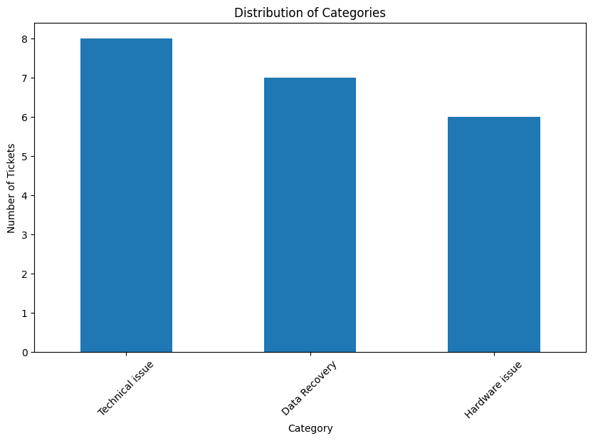

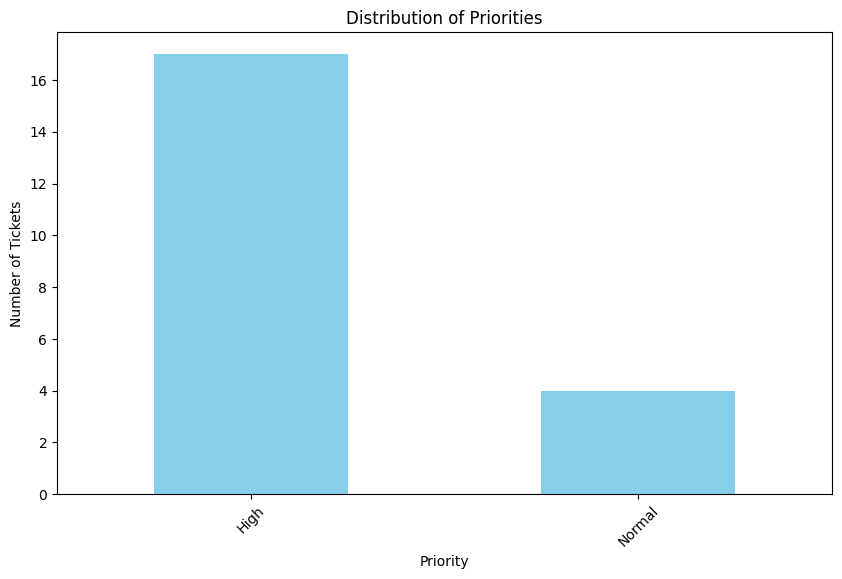

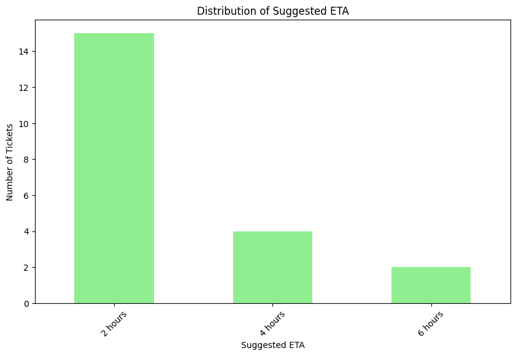

```python
import pandas as pd
import matplotlib.pyplot as plt

# Using the "data.drop" DataFrame
# Distribution of Categories
plt.figure(figsize=(10, 6))
data.drop['category'].value_counts().plot(kind='bar')
plt.title('Distribution of Categories')
plt.ylabel('Number of Tickets')
plt.xlabel('Category')
plt.xticks(rotation=45)
plt.show()

# Distribution of Priorities
plt.figure(figsize=(10, 6))
data.drop['priority'].value_counts().plot(kind='bar', color='skyblue')
plt.title('Distribution of Priorities')
plt.ylabel('Number of Tickets')
plt.xlabel('Priority')
plt.xticks(rotation=45)
plt.show()

# Distribution of Suggested ETA
plt.figure(figsize=(10, 6))
data.drop['suggested_eta'].value_counts().plot(kind='bar', color='lightgreen')
plt.title('Distribution of Suggested ETA')
plt.ylabel('Number of Tickets')
plt.xlabel('Suggested ETA')
plt.xticks(rotation=45)
plt.show()
```

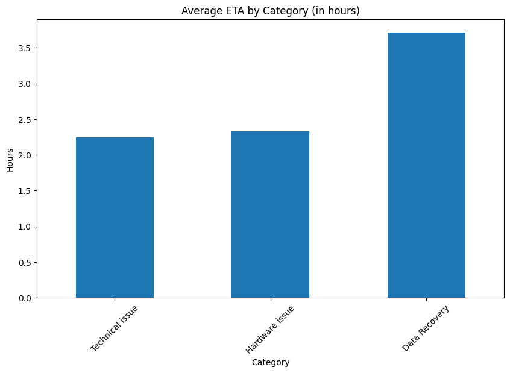

```python
# Average ETA by Category
data.drop['suggested_eta_numeric'] = data.drop['suggested_eta'].str.split().str[0].astype(float)
average_eta_by_category = data.groupby('category')['suggested_eta_numeric'].mean().sort_values()

plt.figure(figsize=(10, 6))
average_eta_by_category.plot(kind='bar')
plt.title('Average ETA by Category (in hours)')
plt.ylabel('Hours')
plt.xlabel('Category')
plt.xticks(rotation=45)
plt.show()
```

```python
data.drop.shape
```

```
(21, 6)
```

```python
category_counts = data['category'].value_counts()
print(category_counts)
```

```
Technical issue    8
Data Recovery      7
Hardware issue     6
Name: category, dtype: int64
```

```python
priority_counts = data['priority'].value_counts()
print(priority_counts)
```

```
High      17
Normal     4
Name: priority, dtype: int64
```

```python
data['suggested_eta_numeric'] = data['suggested_eta'].str.split().str[0].astype(float)
average_eta_by_category = data.groupby('category')['suggested_eta_numeric'].mean()
average_eta_by_priority = data.groupby('priority')['suggested_eta_numeric'].mean()
print(average_eta_by_category)
print(average_eta_by_priority)
```

```
category
Data Recovery      3.714286
Hardware issue     2.333333
Technical issue    2.250000
Name: suggested_eta_numeric, dtype: float64
priority
High      2.823529
Normal    2.500000
Name: suggested_eta_numeric, dtype: float64
```

### **Q6: Share your observations and insights from this exercise, and your recommendations for a business looking to adopt a solution such as this (5 Marks)**

## Business insigts:

- Overall there are 21 customer feedbacks or tickets submitted.
- The tickets will be addressed based on 3 specific buckets- Category, Priority and expected resolution Time.

### In terms of Priority:

- A significant number of tickets are marked as high priority. It's essential to ensure that the support team addresses these tickets promptly to maintain customer trust.
- Regular reviews can be done to ensure that the priority allocation system is effective and that tickets are being correctly categorized.

### In terms of Suggested ETA:

- Most tickets have a suggested ETA of 2 hours. Ensuring that the majority of these tickets are resolved within this timeframe can significantly enhance customer satisfaction.
- Tickets with longer ETAs, like 6 hours, should be monitored to ensure that any delays are communicated to the customer proactively.

## Recommendations for Optimized Customer Experience:

- Proactive Problem Solving: Based on the most common issues, develop FAQs or troubleshooting guides to help customers solve problems on their own.
- Training: Ensure that the support team is well-trained, especially for the most common issues. Consider specialized training for less frequent but complex problems.
- Feedback Loop: After resolving a ticket, seek feedback from customers to understand their experience and areas of improvement.
- Communication: For tickets with longer ETAs, maintain open communication with the customer about the status of their issue.
- Resource Allocation: Allocate more resources during peak times or for high-priority tickets to ensure timely resolution.